# COVID-19 GROWTH FACTOR ANALYSIS

By Matthew

March 31st, 2020

## Introduction

At an abstract level, the growth of COVID-19, or the novel corona virus, can be analyzed by examining the growth factors between the total number of ongoing each cases each day.

This computational process is analagous to examining COVID-19’s growth rate function, `f'(x)`, where `f(x)` represents the total number of COVID-19 cases varying with respect to time.

In this exploratory data analysis, COVID-19’s growth factors will be calculated, beginning with data collected since February 18th, 2020. The growth factors will then be plotted and analyzed to project how COIVD-19 will proliferate in the coming months.

The growth factor will be defined as follows:
$$\small
C = Case \ increase \ on \ a \ given \ day \\
\small
d = Current \ Day \ (d \in \mathbb{Z}) \\
\small
Growth \ Factor = \frac{\Delta C_d}{\Delta C_{d-1}}$$

## Libraries

Required libraries for the analysis are loaded below.

```r
library(knitr)
library(kableExtra)
library(plotly)
```

## Data Sources

Relevant data has been sourced from John Hopkins University and the Center for Systems Science and Engineering (CSSE). It is openly available for viewing [here](https://www.arcgis.com/apps/opsdashboard/index.html#/bda7594740fd40299423467b48e9ecf6).

Due to the quarantine in China and the halt of COVID-19’s spread within China’s borders, Chinese data will be excluded from this analysis. This analysis provides a global view instead, where less stringent control suggests a COVID-19 growth trend that may differ from China’s.

## Data Importation

In the interest of making this report replicable, the relevant data file can be downloaded [here](https://drive.google.com/open?id=1u9a433z7yU_YnNRWSb16eGfB_0cuzDYl).

```r
data = read.csv("COVID-19 - Sheet1.csv")

data$growths = 0
data$deltas = 0

names(data)[1] = "Days Since 2/17"
names(data)[2] = "COVID-19 Case Count"
names(data)[3] = "Growth from Prior Day"
names(data)[4] = "Growth Factors"
```

Calculating data growths from day to day, and then the deltas:

```r
# Calcuate net growths between days
i = 2
while(i <= nrow(data)) {
  data[3][i,] = data[2][i,] - data[2][i - 1,]
  i = i + 1
}

# Calculate growth ratios
i = 3
while(i <= nrow(data)) {
  data[4][i,] = data[3][i,] / data[3][i - 1,]
  i = i + 1
}
```

## Visualization

The current refinded data set is given below. Note that columns three and four necessarily contrain trivial values along the top right diagonal.

```r
kable(data) %>%
  kable_styling(bootstrap_options = c("striped", "hover", "condensed", "responsive"), full_width = T) %>%
  scroll_box(width = "100%", height = "300px", fixed_thead = TRUE)
```

| Days Since 2/17 | COVID-19 Case Count | Growth from Prior Day | Growth Factors |
| --- | --- | --- | --- |
| 1 | 1000 | 0 | 0.0000000 |
| 2 | 1100 | 100 | 0.0000000 |
| 3 | 1200 | 100 | 1.0000000 |
| 4 | 1400 | 200 | 2.0000000 |
| 5 | 1700 | 300 | 1.5000000 |
| 6 | 2000 | 300 | 1.0000000 |
| 7 | 2400 | 400 | 1.3333333 |
| 8 | 2800 | 400 | 1.0000000 |
| 9 | 3300 | 500 | 1.2500000 |
| 10 | 4300 | 1000 | 2.0000000 |
| 11 | 5300 | 1000 | 1.0000000 |
| 12 | 6800 | 1500 | 1.5000000 |
| 13 | 8500 | 1700 | 1.1333333 |
| 14 | 10300 | 1800 | 1.0588235 |
| 15 | 12700 | 2400 | 1.3333333 |
| 16 | 14900 | 2200 | 0.9166667 |
| 17 | 17500 | 2600 | 1.1818182 |
| 18 | 21200 | 3700 | 1.4230769 |
| 19 | 25200 | 4000 | 1.0810811 |
| 20 | 29100 | 3900 | 0.9750000 |
| 21 | 32800 | 3700 | 0.9487179 |
| 22 | 37800 | 5000 | 1.3513514 |
| 23 | 44900 | 7100 | 1.4200000 |
| 24 | 47400 | 2500 | 0.3521127 |
| 25 | 63600 | 16200 | 6.4800000 |
| 26 | 75100 | 11500 | 0.7098765 |
| 27 | 81700 | 6600 | 0.5739130 |
| 28 | 98100 | 16400 | 2.4848485 |

The total number of cases can be modelled against time and displayed as follows:

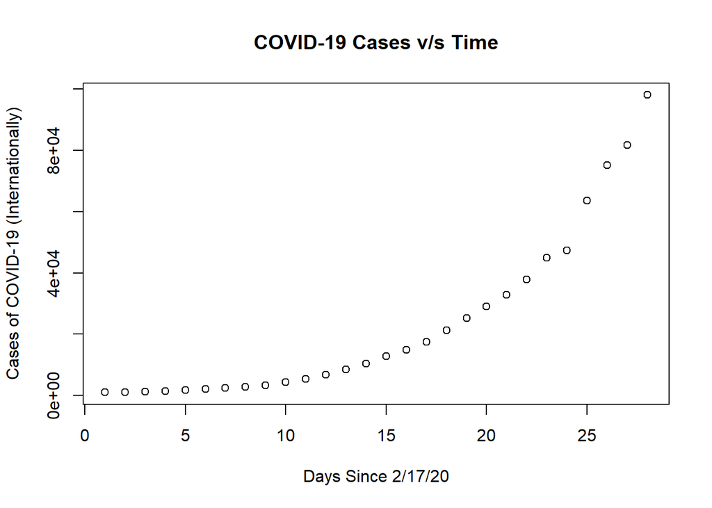

```r
plot(data[2][,], main = "COVID-19 Cases v/s Time", xlab = "Days Since 2/17/20", ylab = "Cases of COVID-19 (Internationally)")
```

As one can observe, the growth is nearly exactly explonential. Understanding the possible severity of future growth can be achieved by plotting the COVID-19 growth ratios, shown below.

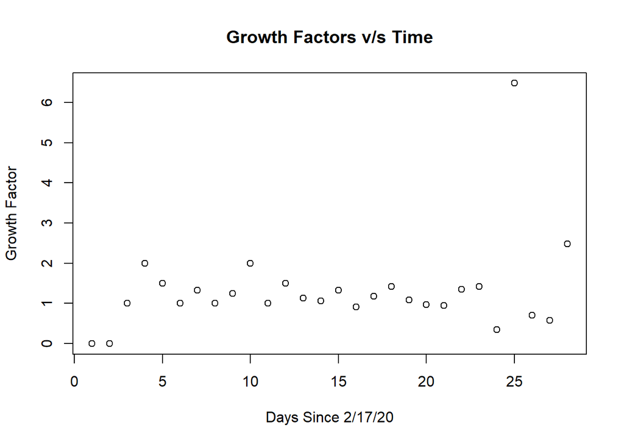

```r
plot(data[4][,], main = "Growth Factors v/s Time", xlab = "Days Since 2/17/20", ylab = "Growth Factor")
```

## Summary Statistics

```r
# Calculate summary statistics
mean = mean(data$`Growth Factor`)
median = median(data$`Growth Factor`)
```

The mean growth factor appears to be 1.3216888. The median growth factor is 1.1072072.

With growth factors are greater than one, that suggests an accelerating rate of increase. Thus, one can infer that COVID-19’s rate of spread is increasing, and will increase for an indeterminate quantity of time. If the growth ratios less than one, that would imply that growth factor is decelerating. Thus, one could infer that the diseaese rate of spread will begin to slow.

In either case, once the growth factors appear to approach one, that means the average amount of cases still left to occur is twice the current amount of cases, by the structure of a logistic curve.